# Lab 1: The One-Group Results File

Bright Joses

2026-11-11

# Part 1: Reproducible workflow

This document combines code, output and interpretation. The data file `COSC_423_Results.csv` sits in the same folder as this `.Rmd`, so it can be re-knitted on any machine.

## Load and tidy the data

The sheet has three header rows (title, maximum marks, column names) and two columns both called “Total” (attendance and final mark), so I skip the header rows and name the 47 columns myself.

```r
col_names <- c("id", paste0("att_", 1:20), "att_total", "att_marks", "att_pct",
               "gender", "cgpa_range", "att_score", paste0("q", 1:6), "quiz",
               "a1", "a2", "assignments", "mid_sem", "ca", "python_lab", "r_lab",
               "exam_raw", "exam_30", "main_exam", "total_score", "grade",
               "pass_fail")

results <- read.csv("COSC_423_Results.csv", skip = 3, header = FALSE,
                    col.names = col_names, stringsAsFactors = FALSE)
results <- results[grepl("^CSA", results$id), ]
results$pass_fail <- factor(results$pass_fail)
results$gender <- factor(results$gender)

head(results[, c("id", "gender", "cgpa_range", "ca", "main_exam",
                 "total_score", "grade", "pass_fail")])
```

```
##       id gender  cgpa_range    ca main_exam total_score grade pass_fail
## 1 CSA001   Male 4.30 - 4.49 36.21     39.29       75.50     B      Pass
## 2 CSA002   Male 3.50 - 3.99 29.04     17.25       46.29     D      Fail
## 3 CSA003   Male 4.30 - 4.49 32.46     35.69       68.15     B      Pass
## 4 CSA004   Male 2.00 - 2.49 20.25     17.65       37.90     F      Fail
## 5 CSA005 Female 4.30 - 4.49 29.64     32.36       62.00     B      Pass
## 6 CSA006   Male 2.50 - 2.99 24.28     28.72       53.00     C      Pass
```

```r
dim(results)
```

```
## [1] 136  47
```

```r
str(results[, c("id", "gender", "ca", "main_exam", "total_score", "grade")])
```

```
## 'data.frame':    136 obs. of  6 variables:
##  $ id         : chr  "CSA001" "CSA002" "CSA003" "CSA004" ...
##  $ gender     : Factor w/ 2 levels "Female","Male": 2 2 2 2 1 2 2 2 1 2 ...
##  $ ca         : num  36.2 29 32.5 20.2 29.6 ...
##  $ main_exam  : num  39.3 17.2 35.7 17.6 32.4 ...
##  $ total_score: num  75.5 46.3 68.2 37.9 62 ...
##  $ grade      : chr  "B" "D" "B" "F" ...
```

```r
sum(is.na(results$total_score))
```

```
## [1] 0
```

There are 136 students and 0 missing final scores. The analysis uses `total_score` (the final mark out of 100).

# Part 2: Descriptive statistics

```r
scores <- results$total_score

mean_score   <- mean(scores, na.rm = TRUE)
median_score <- median(scores, na.rm = TRUE)
mode_score   <- as.numeric(names(sort(table(scores), decreasing = TRUE)[1]))

var_score   <- var(scores, na.rm = TRUE)
sd_score    <- sd(scores, na.rm = TRUE)
range_score <- max(scores, na.rm = TRUE) - min(scores, na.rm = TRUE)
iq_range    <- IQR(scores, na.rm = TRUE)

summary_stats <- data.frame(
  Statistic = c("Mean", "Median", "Mode", "Variance", "Std Dev", "Range", "IQR"),
  Value = round(c(mean_score, median_score, mode_score, var_score, sd_score,
                  range_score, iq_range), 2)
)
summary_stats
```

```
##   Statistic  Value
## 1      Mean  56.05
## 2    Median  60.94
## 3      Mode   0.63
## 4  Variance 339.43
## 5   Std Dev  18.42
## 6     Range  81.98
## 7       IQR  19.37
```

The mean is 56.1 and the median is 60.9. The mean sits below the median, which suggests a left (negative) skew pulled down by low scorers. The standard deviation of 18.4 marks a wide spread across the class. The mode is a weak summary here because scores are continuous and few values repeat.

## Extension: scores by pass/fail and gender

```r
aggregate(total_score ~ pass_fail, data = results,
          FUN = function(x) c(n = length(x), mean = round(mean(x), 1),
                              sd = round(sd(x), 1)))
```

```
##   pass_fail total_score.n total_score.mean total_score.sd
## 1      Fail          36.0             31.3           17.2
## 2      Pass         100.0             65.0            7.4
```

```r
aggregate(total_score ~ gender, data = results,
          FUN = function(x) c(n = length(x), mean = round(mean(x), 1),
                              sd = round(sd(x), 1)))
```

```
##   gender total_score.n total_score.mean total_score.sd
## 1 Female          31.0             65.0           11.0
## 2   Male         105.0             53.4           19.4
```

# Part 3: Distribution and normality

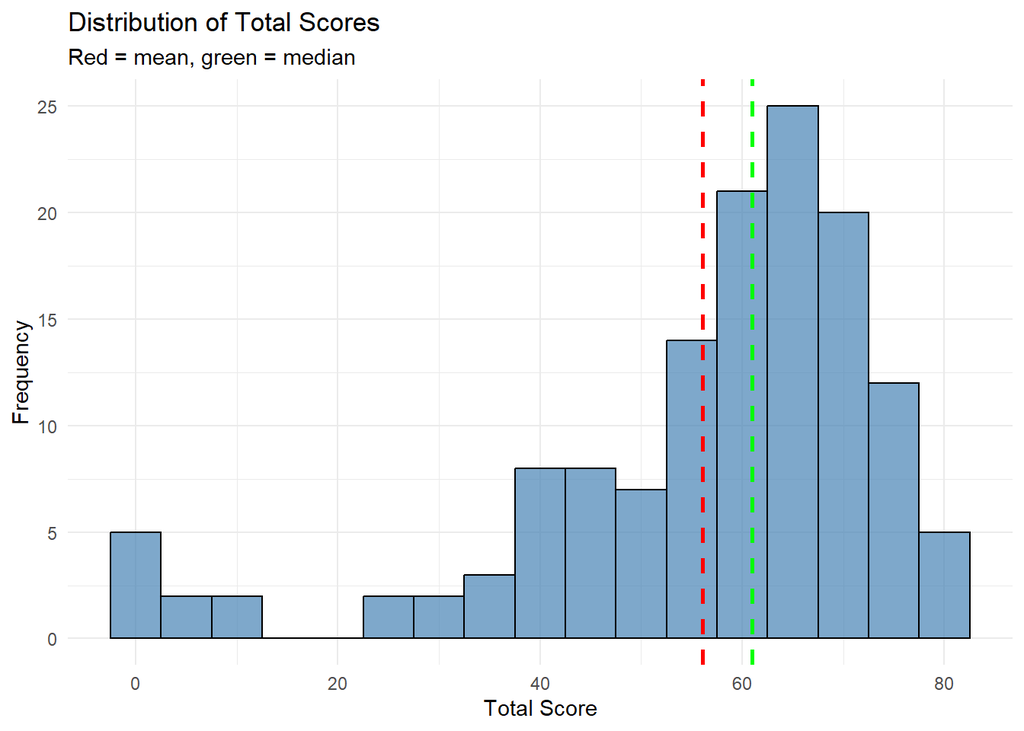

```r
ggplot(results, aes(x = total_score)) +
  geom_histogram(binwidth = 5, fill = "steelblue", color = "black", alpha = 0.7) +
  geom_vline(xintercept = mean_score, color = "red", linetype = "dashed",
             linewidth = 1) +
  geom_vline(xintercept = median_score, color = "green", linetype = "dashed",
             linewidth = 1) +
  labs(title = "Distribution of Total Scores",
       subtitle = "Red = mean, green = median",
       x = "Total Score", y = "Frequency") +
  theme_minimal()
```

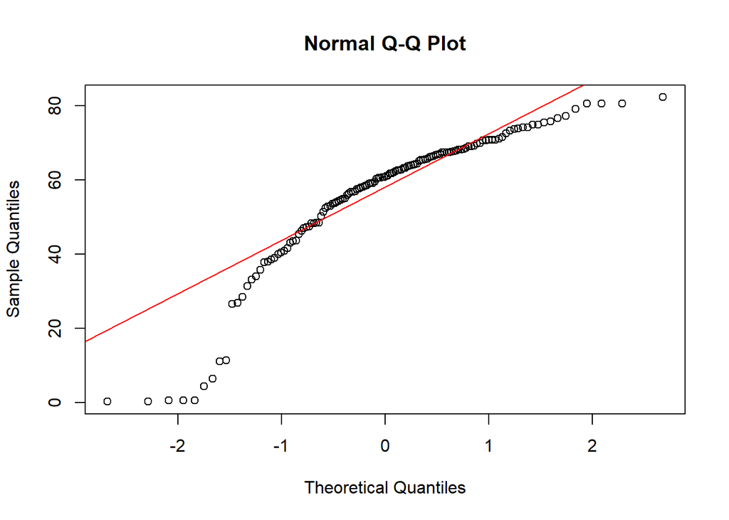

```r
qqnorm(scores)
qqline(scores, col = "red")
```

```r
shapiro_test <- shapiro.test(scores)
shapiro_test
```

```
##
##  Shapiro-Wilk normality test
##
## data:  scores
## W = 0.85746, p-value = 3.984e-10
```

The Shapiro-Wilk test gives W = 0.857 and p = 3.98e-10. Because p < 0.05, we reject normality: the scores are not normally distributed. The histogram shows a cluster of very low scores (students who barely attended or sat the exam) alongside the main group, and the Q-Q plot departs from the line in the tails.

## Scenario reasoning: which distribution fits?

- **Binomial:** A 10-question True/False quiz fits a binomial distribution because each question has two outcomes, there is a fixed number of trials (10), and the probability of success is constant per question.
- **Poisson:** Daily attendance counts fit a Poisson distribution if students arrive independently at a constant average rate.
- **Normal:** Total exam scores often approximate normality through the Central Limit Theorem, because many factors contribute and their sum tends toward a bell curve. This class does not follow that pattern perfectly (see the test above), mainly because of the students with near-zero totals.

# Part 4: One-sample hypothesis test

Test whether the class mean differs from a claimed value of 60.

- H0: mu = 60
- H1: mu != 60 (two-tailed), alpha = 0.05

```r
t_test_result <- t.test(scores, mu = 60, alternative = "two.sided",
                        conf.level = 0.95)
t_test_result
```

```
##
##  One Sample t-test
##
## data:  scores
## t = -2.4986, df = 135, p-value = 0.01367
## alternative hypothesis: true mean is not equal to 60
## 95 percent confidence interval:
##  52.92835 59.17709
## sample estimates:
## mean of x
##  56.05272
```

```r
t_statistic <- t_test_result$statistic
p_value     <- t_test_result$p.value
ci_lower    <- t_test_result$conf.int[1]
ci_upper    <- t_test_result$conf.int[2]

cat("Test Statistic (t):", round(t_statistic, 3), "\n")
```

```
## Test Statistic (t): -2.499
```

```r
cat("P-value:", signif(p_value, 4), "\n")
```

```
## P-value: 0.01367
```

```r
cat("95% Confidence Interval: [", round(ci_lower, 2), ",", round(ci_upper, 2), "]\n")
```

```
## 95% Confidence Interval: [ 52.93 , 59.18 ]
```

## Interpretation

We conducted a one-sample t-test to assess whether the class mean (56.1) differs significantly from the claimed mean of 60. The t-statistic is -2.5 with p = 0.0137. At the alpha = 0.05 level we reject the null hypothesis (p < 0.05). The 95% confidence interval [52.9, 59.2] does not contain 60, so the true mean differs from 60. A Type I error is possible: we may have rejected a true null hypothesis, with probability at most 0.05.

Caveat: the t-test assumes approximately normal data. The Shapiro-Wilk result above shows the scores are not perfectly normal, but with n = 136 the Central Limit Theorem makes the test of the mean reasonably robust. As a non-parametric check I also ran a Wilcoxon signed-rank test:

```r
wilcox_result <- wilcox.test(scores, mu = 60)
wilcox_result
```

```
##
##  Wilcoxon signed rank test with continuity correction
##
## data:  scores
## V = 4338, p-value = 0.4877
## alternative hypothesis: true location is not equal to 60
```

The two tests give different answers (t-test p = 0.0137, Wilcoxon p = 0.488). This is not a contradiction: the t-test compares the **mean** to 60, and the mean (56.1) is pulled down by the left skew, while the Wilcoxon test compares the centre of the distribution, which is closer to the median (60.9), and that is near 60. So the evidence that the typical student scores about 60 is fine, but the average is dragged below 60 by the group of students with near-zero totals. The conclusion about the mean should therefore be reported with this caveat.